# a3_bonus_mujoco_ellawela

## Setup and Reproducibility

```python
# MuJoCo for Hopper-v5
!pip -q install "gymnasium[mujoco]"
```

```
     ━━━━━━━━━━━━━━━━━━━━━━━━━━━━━━━━━━━━━━━━ 42.0/42.0 kB 1.6 MB/s eta 0:00:00
   ━━━━━━━━━━━━━━━━━━━━━━━━━━━━━━━━━━━━━━━━ 6.9/6.9 MB 49.5 MB/s eta 0:00:00
   ━━━━━━━━━━━━━━━━━━━━━━━━━━━━━━━━━━━━━━━━ 243.5/243.5 kB 24.3 MB/s eta 0:00:00
```

**Imports**

```python
import os
import time
import random
from collections import deque

import numpy as np
import torch
import torch.nn as nn
import torch.optim as optim

import gymnasium as gym
import matplotlib.pyplot as plt
```

**Reproducibility**

```python
SEED = 1227
random.seed(SEED)
np.random.seed(SEED)
torch.manual_seed(SEED)
if torch.cuda.is_available():
    torch.cuda.manual_seed_all(SEED)

# Device setup
device = torch.device("cuda" if torch.cuda.is_available() else "cpu")
print(f"Using device: {device} (SEED={SEED})")

# Artifact directories
BONUS_MUJOCO_ARTIFACTS_ROOT = "a3_bonus_mujoco_artifacts"

HOPPER_ENV_ID = "Hopper-v5"
HOPPER_ENV_NAME = "hopper"


os.makedirs(BONUS_MUJOCO_ARTIFACTS_ROOT, exist_ok=True)
HOPPER_ROOT = os.path.join(BONUS_MUJOCO_ARTIFACTS_ROOT, HOPPER_ENV_NAME)
os.makedirs(HOPPER_ROOT, exist_ok=True)
```

```
Using device: cpu (SEED=1227)
```

## 1. Environment helpers

This helper block standardizes how the Hopper-v5 environment is created and seeded for both training and evaluation. The `worker_seed` function deterministically offsets a global `SEED` by worker id, which makes parallel experiments reproducible while still giving each worker a distinct random stream. The `set_env_seed` function seeds the environment, its action space, NumPy, and Python’s `random` module, so that dynamics, action sampling, and any auxiliary randomness are all controlled by the same seed.

The `make_hopper_env` constructor is used for training workers: it builds a Hopper-v5 instance, applies a worker-specific seed, and optionally enables rendering. In contrast, `make_hopper_eval_env` always uses the base seed, so that evaluation episodes are generated from a fixed, repeatable initial condition. Together, these helpers ensure consistent experiment setup and make it possible to reproduce TD3 learning curves and evaluation results.

```python
from gymnasium.wrappers import RecordVideo

def worker_seed(worker_id: int, base_seed: int = SEED) -> int:
    return int(base_seed + 10_000 * worker_id)


def set_env_seed(env: gym.Env, seed: int):
    obs, info = env.reset(seed=seed)
    if hasattr(env.action_space, "seed"):
        env.action_space.seed(seed)
    np.random.seed(seed)
    random.seed(seed)
    return obs, info


def make_hopper_env(
    worker_id: int = 0,
    base_seed: int = SEED,
    render_mode: str | None = None,
) -> gym.Env:

    env = gym.make(HOPPER_ENV_ID, render_mode=render_mode)
    _ = set_env_seed(env, worker_seed(worker_id, base_seed))
    return env


def make_hopper_eval_env(
    base_seed: int = SEED,
    render_mode: str | None = None,
) -> gym.Env:

    env = gym.make(HOPPER_ENV_ID, render_mode=render_mode)
    _ = set_env_seed(env, base_seed)
    return env
```

## 2. Logging and plotting utilities

The `make_run_dir` function creates a dedicated folder for each run under the Hopper artifact root so that logs and figures stay organized and reproducible.

The `moving_average` helper smooths noisy episode returns with a fixed width window and pads the first few entries with NaN. This padding makes it clear where the moving average is not yet defined while still aligning the smoothed curve with the raw episode index.

The `plot_rewards` function takes the list of episode returns, computes a moving average, and saves a figure that overlays the raw and smoothed curves. This gives a clear view of both short term variability and long term learning trends. The `plot_eval_returns` function produces a simpler line plot for evaluation returns across greedy episodes.

```python
def make_run_dir(env_root: str, run_name: str) -> str:
    run_dir = os.path.join(env_root, run_name)
    os.makedirs(run_dir, exist_ok=True)
    return run_dir


def moving_average(x, window: int = 20):
    x = np.asarray(x, dtype=np.float32)
    if x.size == 0:
        return x
    if window <= 1:
        return x

    if x.size < window:
        # Not enough points to compute a full window
        return np.full_like(x, np.nan, dtype=np.float32)

    kernel = np.ones(window, dtype=np.float32) / float(window)
    ma = np.convolve(x, kernel, mode="valid")
    pad = np.full(window - 1, np.nan, dtype=np.float32)
    return np.concatenate([pad, ma])


def plot_rewards(
    rewards,
    run_dir: str,
    filename: str,
    title: str,
    ma_window: int = 20,
):
    rewards = np.asarray(rewards, dtype=np.float32)
    ma = moving_average(rewards, window=ma_window)

    plt.figure(figsize=(8, 4.5))
    plt.plot(rewards, label="Episode return", alpha=0.4)
    plt.plot(ma, label=f"MA({ma_window})")
    plt.xlabel("Episode")
    plt.ylabel("Return")
    plt.title(title)
    plt.legend()
    plt.tight_layout()

    os.makedirs(run_dir, exist_ok=True)
    out_path = os.path.join(run_dir, filename)
    plt.savefig(out_path)
    plt.show()
    plt.close()

    print(f"Saved plot to {out_path}")


def plot_eval_returns(
    returns,
    run_dir: str,
    filename: str,
    title: str,
):
    returns = np.asarray(returns, dtype=np.float32)

    plt.figure(figsize=(8, 4.5))
    plt.plot(range(len(returns)), returns, marker="o")
    plt.xlabel("Episode")
    plt.ylabel("Return")
    plt.title(title)
    plt.tight_layout()

    os.makedirs(run_dir, exist_ok=True)
    out_path = os.path.join(run_dir, filename)
    plt.savefig(out_path)
    plt.show()
    plt.close()

    print(f"Saved eval plot to {out_path}")
```

## 3. TD3 components

### 3.1 Actor and Critic networks

The actor network implements a deterministic policy that maps the continuous Hopper state to a continuous action. It uses a two layer feedforward architecture with ReLU activations and a final linear layer, then applies a tanh nonlinearity and rescales the output to match the environment action bounds. This design keeps the policy simple and stable while ensuring that all actions stay inside the valid control range.

The critic network estimates the state action value function for TD3. It concatenates the observation and action into a single input vector, passes it through the same style of two layer ReLU multilayer perceptron, and outputs a single scalar Q estimate. These actor and critic modules form the core function approximators that TD3 updates during training in order to learn a good control policy on Hopper.

```python
class Actor(nn.Module):

    def __init__(
        self,
        obs_dim: int,
        act_dim: int,
        action_limit: float,
        hidden_sizes=(256, 256),
    ):
        super().__init__()
        self.obs_dim = obs_dim
        self.act_dim = act_dim
        self.action_limit = float(action_limit)

        layers = []
        in_dim = obs_dim
        for h in hidden_sizes:
            layers.append(nn.Linear(in_dim, h))
            layers.append(nn.ReLU())
            in_dim = h
        layers.append(nn.Linear(in_dim, act_dim))

        self.net = nn.Sequential(*layers)

    def forward(self, obs: torch.Tensor) -> torch.Tensor:
        """
        Forward pass for the actor. Outputs deterministic actions in [-action_limit, action_limit].
        """
        x = self.net(obs)
        # tanh squashes to [-1, 1], then scale to environment action limit
        return torch.tanh(x) * self.action_limit


class Critic(nn.Module):
    """
    Q-value network for TD3.
    Maps (state, action) -> scalar Q-value.
    """

    def __init__(
        self,
        obs_dim: int,
        act_dim: int,
        hidden_sizes=(256, 256),
    ):
        super().__init__()
        self.obs_dim = obs_dim
        self.act_dim = act_dim

        layers = []
        in_dim = obs_dim + act_dim
        for h in hidden_sizes:
            layers.append(nn.Linear(in_dim, h))
            layers.append(nn.ReLU())
            in_dim = h
        layers.append(nn.Linear(in_dim, 1))

        self.q_net = nn.Sequential(*layers)

    def forward(self, obs: torch.Tensor, act: torch.Tensor) -> torch.Tensor:
        """
        Forward pass for the critic. Returns Q(s, a) as a 1D tensor.
        """
        x = torch.cat([obs, act], dim=-1)
        q = self.q_net(x)
        return q.squeeze(-1)
```

### 3.2 Replay buffer

The replay buffer stores transitions collected during interaction with the Hopper environment so that TD3 can train off-policy. Each step’s tuple $(s_t, a_t, r_t, s_{t+1}, done_t)$ is written into fixed size NumPy arrays, with a circular pointer that overwrites old data once the capacity is reached. During training, the buffer draws random minibatches of transitions and converts them into PyTorch tensors on the correct device. This breaks the strong temporal correlations in consecutive experience, improves sample efficiency by reusing past data many times, and is essential for stable learning with the TD3 actor critic updates.

```python
class ReplayBuffer:

    def __init__(self, obs_dim: int, act_dim: int, capacity: int = 1_000_000):
        self.capacity = int(capacity)
        self.obs_buf = np.zeros((self.capacity, obs_dim), dtype=np.float32)
        self.next_obs_buf = np.zeros((self.capacity, obs_dim), dtype=np.float32)
        self.act_buf = np.zeros((self.capacity, act_dim), dtype=np.float32)
        self.rew_buf = np.zeros(self.capacity, dtype=np.float32)
        self.done_buf = np.zeros(self.capacity, dtype=np.float32)

        self.ptr = 0
        self.size = 0

    def store(
        self,
        obs: np.ndarray,
        act: np.ndarray,
        rew: float,
        next_obs: np.ndarray,
        done: bool,
    ):
        idx = self.ptr
        self.obs_buf[idx] = obs
        self.act_buf[idx] = act
        self.rew_buf[idx] = rew
        self.next_obs_buf[idx] = next_obs
        self.done_buf[idx] = float(done)

        self.ptr = (self.ptr + 1) % self.capacity
        self.size = min(self.size + 1, self.capacity)

    def sample_batch(self, batch_size: int = 256):
        assert self.size > 0, "ReplayBuffer is empty."
        batch_size = min(batch_size, self.size)
        idxs = np.random.randint(0, self.size, size=batch_size)

        obs = torch.as_tensor(self.obs_buf[idxs], dtype=torch.float32, device=device)
        acts = torch.as_tensor(self.act_buf[idxs], dtype=torch.float32, device=device)
        rews = torch.as_tensor(self.rew_buf[idxs], dtype=torch.float32, device=device)
        next_obs = torch.as_tensor(
            self.next_obs_buf[idxs], dtype=torch.float32, device=device
        )
        dones = torch.as_tensor(self.done_buf[idxs], dtype=torch.float32, device=device)

        return {
            "obs": obs,
            "acts": acts,
            "rews": rews,
            "next_obs": next_obs,
            "dones": dones,
        }
```

### 3.3 TD3 agent

The agent holds one actor network and two independent critic networks, together with corresponding target copies for each network. The critics learn to approximate the Q value of a state action pair while the actor learns a deterministic policy that maximizes the first critic.

The constructor sets all core hyperparameters such as the discount factor, soft update rate, target policy noise, noise clipping, and the frequency of delayed policy updates, and wires up Adam optimizers for actor and critics. The `select_action` method converts a NumPy observation into a torch tensor, runs it through the actor, and optionally adds Gaussian exploration noise before clipping to the action limits.

The `train_step` method then performs the TD3 update using a minibatch from the replay buffer. It first builds a target action by passing next states through the target actor and adding clipped noise in order to smooth the target policy. Target Q values are computed by taking the minimum of the two target critics which reduces overestimation bias.

The two main critics are updated by minimizing the sum of squared errors between current and target Q values. The actor parameters are updated less frequently according to `policy_delay` so that the critics remain accurate while the policy changes. Whenever the actor is updated, the target networks are moved toward the main networks via a soft update controlled by `tau`. The method returns a small dictionary of losses that can be logged during training.

```python
class TD3Agent:

    def __init__(
        self,
        obs_dim: int,
        act_dim: int,
        action_limit: float,
        actor_hidden_sizes=(256, 256),
        critic_hidden_sizes=(256, 256),
        actor_lr: float = 3e-4,
        critic_lr: float = 3e-4,
        gamma: float = 0.99,
        tau: float = 5e-3,
        policy_noise: float = 0.2,
        noise_clip: float = 0.5,
        policy_delay: int = 2,
    ):
        self.obs_dim = obs_dim
        self.act_dim = act_dim
        self.action_limit = float(action_limit)

        self.gamma = gamma
        self.tau = tau
        self.policy_noise = policy_noise
        self.noise_clip = noise_clip
        self.policy_delay = policy_delay

        # Main networks
        self.actor = Actor(obs_dim, act_dim, self.action_limit, actor_hidden_sizes).to(device)
        self.critic1 = Critic(obs_dim, act_dim, critic_hidden_sizes).to(device)
        self.critic2 = Critic(obs_dim, act_dim, critic_hidden_sizes).to(device)

        # Target networks (initialized with same weights)
        self.actor_target = Actor(obs_dim, act_dim, self.action_limit, actor_hidden_sizes).to(device)
        self.critic1_target = Critic(obs_dim, act_dim, critic_hidden_sizes).to(device)
        self.critic2_target = Critic(obs_dim, act_dim, critic_hidden_sizes).to(device)

        self.actor_target.load_state_dict(self.actor.state_dict())
        self.critic1_target.load_state_dict(self.critic1.state_dict())
        self.critic2_target.load_state_dict(self.critic2.state_dict())

        # Optimizers
        self.actor_optimizer = optim.Adam(self.actor.parameters(), lr=actor_lr)
        self.critic1_optimizer = optim.Adam(self.critic1.parameters(), lr=critic_lr)
        self.critic2_optimizer = optim.Adam(self.critic2.parameters(), lr=critic_lr)

        # Internal counter for delayed policy updates
        self.total_updates = 0

    @torch.no_grad()
    def select_action(self, obs: np.ndarray, noise_scale: float = 0.0) -> np.ndarray:

        obs_t = torch.as_tensor(obs, dtype=torch.float32, device=device).unsqueeze(0)
        action = self.actor(obs_t).squeeze(0).cpu().numpy()

        if noise_scale > 0.0:
            noise = np.random.normal(loc=0.0, scale=noise_scale, size=self.act_dim)
            action = action + noise
        action = np.clip(action, -self.action_limit, self.action_limit)
        return action

    def _soft_update(self, source: nn.Module, target: nn.Module):
        """
        target = tau * source + (1 - tau) * target
        """
        for param, target_param in zip(source.parameters(), target.parameters()):
            target_param.data.mul_(1.0 - self.tau)
            target_param.data.add_(self.tau * param.data)

    def train_step(self, replay_buffer: ReplayBuffer, batch_size: int = 256):

        if replay_buffer.size < batch_size:
            return {}

        batch = replay_buffer.sample_batch(batch_size)
        obs = batch["obs"]
        acts = batch["acts"]
        rews = batch["rews"]
        next_obs = batch["next_obs"]
        dones = batch["dones"]


        # Critic update
        with torch.no_grad():
            # Target actions with smoothing noise
            next_actions = self.actor_target(next_obs)
            noise = torch.randn_like(next_actions) * self.policy_noise
            noise = torch.clamp(noise, -self.noise_clip, self.noise_clip)
            next_actions = next_actions + noise
            next_actions = torch.clamp(next_actions, -self.action_limit, self.action_limit)

            # Target Q-values
            target_q1 = self.critic1_target(next_obs, next_actions)
            target_q2 = self.critic2_target(next_obs, next_actions)
            target_q = torch.min(target_q1, target_q2)
            target = rews + self.gamma * (1.0 - dones) * target_q

        # Current Q estimates
        current_q1 = self.critic1(obs, acts)
        current_q2 = self.critic2(obs, acts)

        critic1_loss = nn.MSELoss()(current_q1, target)
        critic2_loss = nn.MSELoss()(current_q2, target)
        critic_loss = critic1_loss + critic2_loss

        self.critic1_optimizer.zero_grad()
        self.critic2_optimizer.zero_grad()
        critic_loss.backward()
        self.critic1_optimizer.step()
        self.critic2_optimizer.step()

        actor_loss_value = None


        # Delayed policy update
        self.total_updates += 1
        if self.total_updates % self.policy_delay == 0:
            # Actor aims to maximize Q1(s, π(s))
            actor_actions = self.actor(obs)
            actor_loss = -self.critic1(obs, actor_actions).mean()

            self.actor_optimizer.zero_grad()
            actor_loss.backward()
            self.actor_optimizer.step()

            # Update target networks
            self._soft_update(self.actor, self.actor_target)
            self._soft_update(self.critic1, self.critic1_target)
            self._soft_update(self.critic2, self.critic2_target)

            actor_loss_value = actor_loss.item()

        # Prepare loss dict for optional logging
        info = {
            "critic_loss": critic_loss.item(),
            "critic1_loss": critic1_loss.item(),
            "critic2_loss": critic2_loss.item(),
        }
        if actor_loss_value is not None:
            info["actor_loss"] = actor_loss_value

        return info
```

## 4. TD3 training on Hopper v5

This function trains a TD3 agent on Hopper-v5 for a fixed number of environment steps. It creates a run directory, builds the environment, initializes the replay buffer and agent, and then runs a single-env loop with an initial random exploration phase followed by TD3 policy updates from replay. After training, it saves episode returns and lengths, plots the training curve, and writes the actor and critic weights into the run directory so the policy can be reused for evaluation.

```python
def train_td3_on_hopper(
    run_name: str,
    total_env_steps: int = 500_000,
    start_steps: int = 10_000,
    batch_size: int = 256,
    expl_noise: float = 0.1,
    gamma: float = 0.99,
    tau: float = 5e-3,
    policy_noise: float = 0.2,
    noise_clip: float = 0.5,
    policy_delay: int = 2,
    actor_lr: float = 3e-4,
    critic_lr: float = 3e-4,
    buffer_capacity: int = 1_000_000,
    log_every: int = 10_000,
) -> tuple[TD3Agent, dict]:

    # Per run directory and logging structures
    run_dir = make_run_dir(HOPPER_ROOT, run_name)
    print(f"Running TD3 on {HOPPER_ENV_ID} | run_dir={run_dir}")

    # Environment for training
    env = make_hopper_env(worker_id=0, base_seed=SEED, render_mode=None)

    obs_space = env.observation_space
    act_space = env.action_space

    assert isinstance(act_space, gym.spaces.Box), "Hopper-v5 must have a Box action space."

    obs_dim = obs_space.shape[0]
    act_dim = act_space.shape[0]
    # Hopper has symmetric action bounds; take the max absolute value as the limit
    action_limit = float(act_space.high[0])

    # Replay buffer and agent
    replay_buffer = ReplayBuffer(obs_dim, act_dim, capacity=buffer_capacity)
    agent = TD3Agent(
        obs_dim=obs_dim,
        act_dim=act_dim,
        action_limit=action_limit,
        actor_hidden_sizes=(256, 256),
        critic_hidden_sizes=(256, 256),
        actor_lr=actor_lr,
        critic_lr=critic_lr,
        gamma=gamma,
        tau=tau,
        policy_noise=policy_noise,
        noise_clip=noise_clip,
        policy_delay=policy_delay,
    )

    # Training loop state
    episode_returns = []
    episode_lengths = []

    ep_ret = 0.0
    ep_len = 0
    obs, info = env.reset()

    start_time = time.time()
    total_steps = 0

    while total_steps < total_env_steps:

        # Action selection
        if total_steps < start_steps:
            # Initial exploration with random policy
            action = act_space.sample()
        else:
            # TD3 policy with exploration noise
            action = agent.select_action(obs, noise_scale=expl_noise)

        next_obs, reward, terminated, truncated, info = env.step(action)
        done = terminated or truncated

        # Store transition
        replay_buffer.store(obs, action, reward, next_obs, done)

        obs = next_obs
        ep_ret += reward
        ep_len += 1
        total_steps += 1


        # TD3 updates after warm up
        if total_steps >= start_steps:
            _ = agent.train_step(replay_buffer, batch_size=batch_size)


        # Episode end handling
        if done:
            episode_returns.append(ep_ret)
            episode_lengths.append(ep_len)

            # Log basic episode info
            if len(episode_returns) % 10 == 0:
                recent = episode_returns[-10:]
                avg_recent = np.mean(recent)
                print(
                    f"[TD3][Hopper] episodes={len(episode_returns):4d} "
                    f"steps={total_steps:7d} "
                    f"ep_ret={ep_ret:8.2f} ep_len={ep_len:4d} "
                    f"avg10={avg_recent:8.2f}"
                )

            # Reset episode
            ep_ret = 0.0
            ep_len = 0
            obs, info = env.reset()


        # Periodic logging by steps
        if total_steps % log_every == 0:
            if episode_returns:
                avg_last = (
                    np.mean(episode_returns[-50:])
                    if len(episode_returns) >= 50
                    else np.mean(episode_returns)
                )
                elapsed = time.time() - start_time
                print(
                    f"[TD3][Hopper] steps={total_steps:7d} "
                    f"episodes={len(episode_returns):4d} "
                    f"avg_return_recent={avg_last:8.2f} "
                    f"elapsed={elapsed:7.1f}s"
                )

    env.close()

    # Save raw rewards and lengths
    rewards_path = os.path.join(run_dir, "train_episode_returns.npy")
    lengths_path = os.path.join(run_dir, "train_episode_lengths.npy")
    np.save(rewards_path, np.asarray(episode_returns, dtype=np.float32))
    np.save(lengths_path, np.asarray(episode_lengths, dtype=np.int32))
    print(f"Saved training returns to {rewards_path}")
    print(f"Saved training lengths to {lengths_path}")

    # Plot training curve
    if episode_returns:
        plot_rewards(
            rewards=episode_returns,
            run_dir=run_dir,
            filename="td3_hopper_train_rewards.png",
            title=f"TD3 on {HOPPER_ENV_ID} - training returns",
            ma_window=20,
        )

    # Save trained weights for this run (actor + twin critics)
    actor_path = os.path.join(run_dir, "td3_hopper_actor.pth")
    critics_path = os.path.join(run_dir, "td3_hopper_critics.pth")

    torch.save(agent.actor.state_dict(), actor_path)
    torch.save(
        {
            "critic1": agent.critic1.state_dict(),
            "critic2": agent.critic2.state_dict(),
        },
        critics_path,
    )
    print(f"Saved TD3 Hopper actor to {actor_path}")
    print(f"Saved TD3 Hopper critics to {critics_path}")

    info = {
        "run_dir": run_dir,
        "episode_returns": episode_returns,
        "episode_lengths": episode_lengths,
    }
    return agent, info
```

## 5. Greedy evaluation

This function runs a greedy (noise-free) evaluation of the trained TD3 policy on Hopper-v5. It creates a separate eval environment with a fixed seed, rolls out `num_episodes` using `select_action` with `noise_scale=0`, and records the return and length of each episode. The raw evaluation returns and lengths are saved as NumPy arrays in the same run directory, a simple line plot of episode returns is generated, and the function prints and returns the mean and standard deviation of the evaluation performance.

```python
def evaluate_td3_on_hopper(
    agent: TD3Agent,
    run_dir: str,
    num_episodes: int = 10,
) -> dict:

    env = make_hopper_eval_env(base_seed=SEED, render_mode=None)

    eval_returns = []
    eval_lengths = []

    for ep in range(num_episodes):
        obs, info = env.reset()
        done = False
        ep_ret = 0.0
        ep_len = 0

        while not done:
            action = agent.select_action(obs, noise_scale=0.0)
            obs, reward, terminated, truncated, info = env.step(action)
            done = terminated or truncated

            ep_ret += reward
            ep_len += 1

        eval_returns.append(ep_ret)
        eval_lengths.append(ep_len)
        print(f"Eval episode {ep + 1:2d} return {ep_ret:8.2f} steps {ep_len:4d}")

    env.close()

    eval_returns = np.asarray(eval_returns, dtype=np.float32)
    eval_lengths = np.asarray(eval_lengths, dtype=np.int32)

    # Save raw evaluation data
    returns_path = os.path.join(run_dir, "td3_hopper_eval_returns.npy")
    lengths_path = os.path.join(run_dir, "td3_hopper_eval_lengths.npy")
    np.save(returns_path, eval_returns)
    np.save(lengths_path, eval_lengths)
    print(f"Saved eval returns to {returns_path}")
    print(f"Saved eval lengths to {lengths_path}")

    # Summary statistics and plot
    mean_ret = float(np.mean(eval_returns))
    std_ret = float(np.std(eval_returns))
    print(f"Greedy evaluation mean {mean_ret:.2f}  std {std_ret:.2f}")

    plot_eval_returns(
        returns=eval_returns,
        run_dir=run_dir,
        filename="td3_hopper_eval_rewards.png",
        title=f"TD3 on {HOPPER_ENV_ID} - greedy evaluation returns",
    )

    return {
        "eval_returns": eval_returns,
        "eval_lengths": eval_lengths,
        "mean_return": mean_ret,
        "std_return": std_ret,
    }
```

## 6. Running TD3–Hopper experiments

This launches the main TD3 training run on Hopper-v5 using the hyperparameters chosen for the experiment. It trains the agent for 500,000 environment steps, logs episode returns, saves learning curves and network weights under a dedicated run directory, and returns both the trained TD3Agent (`agent_run0`) and a small info dictionary (`info_run0`) containing the run path and raw training data for later analysis and evaluation.

**Training - Run#0**

```
Running TD3 on Hopper-v5 | run_dir=a3_bonus_mujoco_artifacts/hopper/run_0_hopper_td3
[TD3][Hopper] episodes=  10 steps=    250 ep_ret=   73.02 ep_len=  48 avg10=   22.94
[TD3][Hopper] episodes=  20 steps=    473 ep_ret=   13.47 ep_len=  15 avg10=   15.11
[TD3][Hopper] episodes=  30 steps=    667 ep_ret=   12.75 ep_len=  15 avg10=   11.73
[TD3][Hopper] episodes=  40 steps=    859 ep_ret=    9.40 ep_len=  20 avg10=   15.47
[TD3][Hopper] episodes=  50 steps=   1135 ep_ret=   67.95 ep_len=  52 avg10=   22.75
[TD3][Hopper] episodes=  60 steps=   1402 ep_ret=   37.23 ep_len=  33 avg10=   20.96
[TD3][Hopper] episodes=  70 steps=   1644 ep_ret=   15.86 ep_len=  24 avg10=   19.76
[TD3][Hopper] episodes=  80 steps=   1905 ep_ret=   13.23 ep_len=  17 avg10=   21.83
[TD3][Hopper] episodes=  90 steps=   2123 ep_ret=   30.34 ep_len=  30 avg10=   18.96
[TD3][Hopper] episodes= 100 steps=   2439 ep_ret=   23.92 ep_len=  27 avg10=   30.79
[TD3][Hopper] episodes= 110 steps=   2682 ep_ret=   14.28 ep_len=  19 avg10=   17.09
[TD3][Hopper] episodes= 120 steps=   2891 ep_ret=   10.35 ep_len=  25 avg10=   10.80
[TD3][Hopper] episodes= 130 steps=   3112 ep_ret=   23.53 ep_len=  20 avg10=   19.48
[TD3][Hopper] episodes= 140 steps=   3367 ep_ret=   21.60 ep_len=  24 avg10=   23.95
[TD3][Hopper] episodes= 150 steps=   3593 ep_ret=    6.56 ep_len=  10 avg10=   16.45
[TD3][Hopper] episodes= 160 steps=   3771 ep_ret=   12.42 ep_len=  17 avg10=   10.55
[TD3][Hopper] episodes= 170 steps=   3981 ep_ret=   22.60 ep_len=  48 avg10=   11.81
[TD3][Hopper] episodes= 180 steps=   4173 ep_ret=   41.16 ep_len=  39 avg10=   14.46
[TD3][Hopper] episodes= 190 steps=   4418 ep_ret=   22.02 ep_len=  28 avg10=   17.50
[TD3][Hopper] episodes= 200 steps=   4634 ep_ret=    8.76 ep_len=  13 avg10=   13.51
[TD3][Hopper] episodes= 210 steps=   4907 ep_ret=   20.56 ep_len=  28 avg10=   26.28
[TD3][Hopper] episodes= 220 steps=   5087 ep_ret=   10.66 ep_len=  14 avg10=   13.20
[TD3][Hopper] episodes= 230 steps=   5293 ep_ret=   19.08 ep_len=  21 avg10=   14.45
[TD3][Hopper] episodes= 240 steps=   5468 ep_ret=    9.47 ep_len=  13 avg10=   13.12
[TD3][Hopper] episodes= 250 steps=   5733 ep_ret=   10.45 ep_len=  14 avg10=   19.97
[TD3][Hopper] episodes= 260 steps=   5956 ep_ret=    8.06 ep_len=  11 avg10=   16.60
[TD3][Hopper] episodes= 270 steps=   6179 ep_ret=   10.17 ep_len=  20 avg10=   18.86
[TD3][Hopper] episodes= 280 steps=   6420 ep_ret=   20.47 ep_len=  30 avg10=   18.54
[TD3][Hopper] episodes= 290 steps=   6683 ep_ret=   13.74 ep_len=  41 avg10=   17.64
[TD3][Hopper] episodes= 300 steps=   6956 ep_ret=    9.27 ep_len=  13 avg10=   23.50
[TD3][Hopper] episodes= 310 steps=   7158 ep_ret=   14.05 ep_len=  17 avg10=   21.39
[TD3][Hopper] episodes= 320 steps=   7336 ep_ret=    9.57 ep_len=  14 avg10=   12.17
[TD3][Hopper] episodes= 330 steps=   7583 ep_ret=    8.02 ep_len=  10 avg10=   20.58
[TD3][Hopper] episodes= 340 steps=   7793 ep_ret=   50.93 ep_len=  38 avg10=   19.10
[TD3][Hopper] episodes= 350 steps=   7992 ep_ret=    7.43 ep_len=  12 avg10=   14.08
[TD3][Hopper] episodes= 360 steps=   8235 ep_ret=   18.18 ep_len=  20 avg10=   24.32
[TD3][Hopper] episodes= 370 steps=   8429 ep_ret=   12.68 ep_len=  14 avg10=   14.78
[TD3][Hopper] episodes= 380 steps=   8622 ep_ret=   29.76 ep_len=  25 avg10=   13.74
[TD3][Hopper] episodes= 390 steps=   8778 ep_ret=   19.74 ep_len=  21 avg10=   10.70
```

[output cut: 205 more lines]

```
[TD3][Hopper] episodes=2010 steps= 444449 ep_ret= 3217.97 ep_len=1000 avg10= 2950.82
[TD3][Hopper] steps= 450000 episodes=2018 avg_return_recent= 2587.56 elapsed= 7214.5s
[TD3][Hopper] episodes=2020 steps= 451132 ep_ret= 1239.01 ep_len= 373 avg10= 2225.67
[TD3][Hopper] episodes=2030 steps= 459024 ep_ret= 1921.78 ep_len= 587 avg10= 2594.70
[TD3][Hopper] steps= 460000 episodes=2031 avg_return_recent= 2671.32 elapsed= 7379.3s
[TD3][Hopper] episodes=2040 steps= 466558 ep_ret= 1510.96 ep_len= 466 avg10= 2482.75
[TD3][Hopper] steps= 470000 episodes=2043 avg_return_recent= 2667.18 elapsed= 7543.2s
[TD3][Hopper] episodes=2050 steps= 473589 ep_ret= 2270.01 ep_len= 670 avg10= 2315.70
[TD3][Hopper] steps= 480000 episodes=2056 avg_return_recent= 2489.99 elapsed= 7710.6s
[TD3][Hopper] episodes=2060 steps= 482873 ep_ret= 3218.22 ep_len=1000 avg10= 3025.66
[TD3][Hopper] steps= 490000 episodes=2067 avg_return_recent= 2647.06 elapsed= 7875.5s
[TD3][Hopper] episodes=2070 steps= 492725 ep_ret= 3193.06 ep_len=1000 avg10= 3158.45
[TD3][Hopper] steps= 500000 episodes=2077 avg_return_recent= 2811.23 elapsed= 8042.3s
Saved training returns to a3_bonus_mujoco_artifacts/hopper/run_0_hopper_td3/train_episode_returns.npy
Saved training lengths to a3_bonus_mujoco_artifacts/hopper/run_0_hopper_td3/train_episode_lengths.npy
```

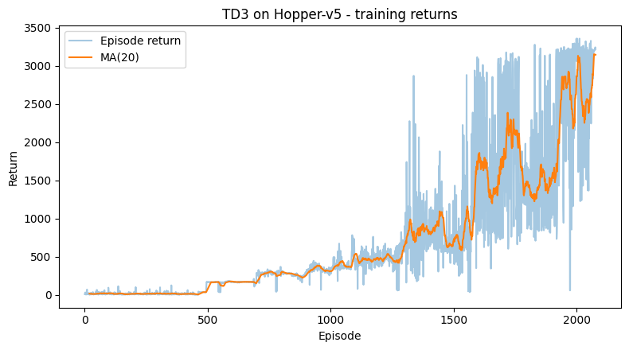

```
Saved plot to a3_bonus_mujoco_artifacts/hopper/run_0_hopper_td3/td3_hopper_train_rewards.png
Saved TD3 Hopper actor to a3_bonus_mujoco_artifacts/hopper/run_0_hopper_td3/td3_hopper_actor.pth
Saved TD3 Hopper critics to a3_bonus_mujoco_artifacts/hopper/run_0_hopper_td3/td3_hopper_critics.pth

Finished training run: run_0_hopper_td3
Run directory: a3_bonus_mujoco_artifacts/hopper/run_0_hopper_td3
```

```python
run_name = "run_0_hopper_td3"

agent_run0, info_run0 = train_td3_on_hopper(
    run_name=run_name,
    total_env_steps=500_000,
    start_steps=10_000,
    batch_size=256,
    expl_noise=0.1,
    gamma=0.99,
    tau=5e-3,
    policy_noise=0.2,
    noise_clip=0.5,
    policy_delay=2,
    actor_lr=3e-4,
    critic_lr=3e-4,
    buffer_capacity=1_000_000,
    log_every=10_000,
)

run_dir_run0 = info_run0["run_dir"]
print(f"\nFinished training run: {run_name}")
print(f"Run directory: {run_dir_run0}")
```

**Greedy Evaluation**

This runs a greedy evaluation of the trained TD3 agent on Hopper v5. It rolls out ten episodes with deterministic actions, saves the evaluation returns and lengths in the same run directory, and prints a short summary of the mean and standard deviation of the returns for Run#0.

```
Eval episode  1 return  3178.62 steps 1000
Eval episode  2 return  3185.27 steps 1000
Eval episode  3 return  3159.56 steps 1000
Eval episode  4 return  3158.36 steps 1000
Eval episode  5 return  3163.52 steps 1000
Eval episode  6 return  3154.91 steps 1000
Eval episode  7 return  3174.14 steps 1000
Eval episode  8 return  3178.77 steps 1000
Eval episode  9 return  3161.71 steps 1000
Eval episode 10 return  3168.61 steps 1000
Saved eval returns to a3_bonus_mujoco_artifacts/hopper/run_0_hopper_td3/td3_hopper_eval_returns.npy
Saved eval lengths to a3_bonus_mujoco_artifacts/hopper/run_0_hopper_td3/td3_hopper_eval_lengths.npy
Greedy evaluation mean 3168.35  std 9.79
```

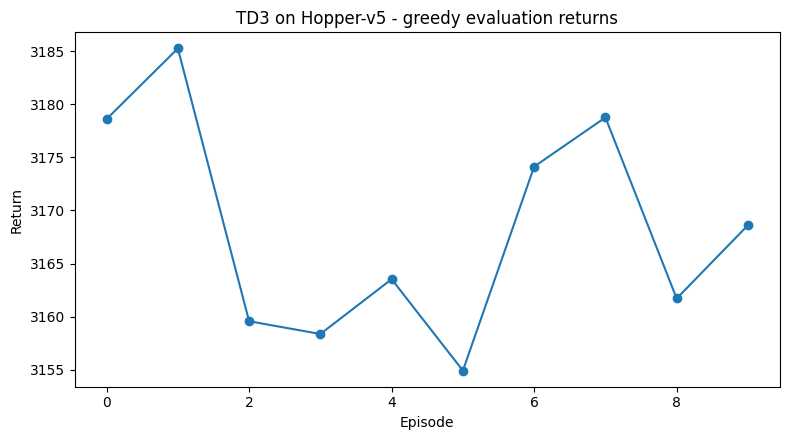

```
Saved eval plot to a3_bonus_mujoco_artifacts/hopper/run_0_hopper_td3/td3_hopper_eval_rewards.png
[TD3][Hopper][run0] Greedy evaluation mean=3168.35 std=9.79
```

```python
eval_info_run0 = evaluate_td3_on_hopper(
    agent=agent_run0,
    run_dir=run_dir_run0,
    num_episodes=10,
)

print(
    f"[TD3][Hopper][run0] Greedy evaluation mean={eval_info_run0['mean_return']:.2f} "
    f"std={eval_info_run0['std_return']:.2f}"
)
```